# Overview: Creating FFTs with FFTrees

Nathaniel D. Phillips and Hansjörg Neth

2023-06-06

The R package **FFTrees** (Phillips et al., 2017, 2023) makes it easy to create, visualize, and evaluate fast-and-frugal decision trees (FFTs). FFTs are simple and transparent decision algorithms for solving binary classification problems in an effective and efficient fashion.

## Fast-and-Frugal Trees (FFTs)

A *fast-and-frugal tree* (FFT) (Martignon et al., 2003) is a set of hierarchical rules for solving binary classification tasks based on very little pieces of information (usually using 4 or fewer cues). In contrast to more complex decision trees, each node of an FFT has exactly two branches. A branch can either contain another cue (i.e., ask another question) or lead to an exit (i.e., yield a decision or prediction outcome).  
Each non-final node of an FFT has one exit branch and the final node has two exit branches.

FFTs are simple and effective decision strategies that use minimal information for making decisions in binary classification problems (Gigerenzer et al., 1999; see Gigerenzer & Todd, 1999). FFTs are often preferable to more complex decision strategies (such as logistic regression, LR) because they rarely over-fit data (Gigerenzer & Brighton, 2009) and are easy to interpret, implement, and communicate in real-world settings (Marewski & Gigerenzer, 2012). FFTs have been designed to tackle many real world tasks from making fast decisions in emergency rooms (Green & Mehr, 1997) to detecting depression (Jenny et al., 2013).

Whereas their performance and success are empirical questions, a key theoretical advantage of FFTs is their *transparency* to decision makers and anyone aiming to understand and evaluate the details of an algorithm. In the words of Burton et al. (2020), “human users could interpret, justify, control, and interact with a fast-and-frugal decision aid” (p. 229).

## Using the FFTrees package

The **FFTrees** package makes it easy to produce, display, and evaluate FFTs (Phillips et al., 2017). The package’s main function is `FFTrees()` which takes formula `formula` and dataset `data` arguments and returns several FFTs that attempt to classify training cases into criterion classes. The FFTs created can then be used to predict new data to cross-validate their performance.

Here is an example of using the main `FFTrees()` function to fit FFTs to `heart.train` data:

```r
# Create a fast-and-frugal tree (FFT) predicting heart disease:
heart.fft <- FFTrees(formula = diagnosis ~.,
                     data = heart.train,
                     data.test = heart.test,
                     main = "Heart Disease",
                     decision.labels = c("Healthy", "Diseased"))
```

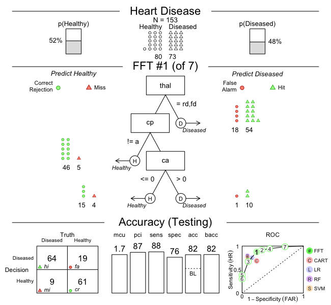

A fast-and-frugal tree (FFT) to predict heart disease status.

```r
# Visualize predictive performance:
plot(heart.fft, data = "test")
```

## Getting started

To start using the **FFTrees** package, we recommend studying the Tutorial: Creating FFTs for heart disease. The tutorial illustrates the basics steps of creating, visualizing, and evaluating fast-and-frugal trees (FFTs). The scientific background of FFTs and the development of **FFTrees** are described in Phillips et al. (2017) (doi 10.1017/S1930297500006239 | html | [PDF](https://journal.sjdm.org/17/17217/jdm17217.pdf)). The following vignettes provide details on related topics and corresponding examples.

### Vignettes

Here is a complete list of the vignettes available in the **FFTrees** package:

|  | Vignette | Description |
| --- | --- | --- |
|  | Main guide: FFTrees overview | An overview of the **FFTrees** package |
| 1 | Tutorial: FFTs for heart disease | An example of using `FFTrees()` to model heart disease diagnosis |
| 2 | Accuracy statistics | Definitions of accuracy statistics used throughout the package |
| 3 | Creating FFTs with FFTrees() | Details on the main `FFTrees()` function |
| 4 | Manually specifying FFTs | How to directly create FFTs without using the built-in algorithms |
| 5 | Visualizing FFTs | Plotting `FFTrees` objects, from full trees to icon arrays |
| 6 | Examples of FFTs | Examples of FFTs from different datasets contained in the package |

### Datasets

The **FFTrees** package contains several datasets — mostly from the [UCI Machine Learning Repository](https://archive.ics.uci.edu/ml/) — that allow you to address interesting questions when exploring FFTs:

- `blood` – Which people donate blood? [source](https://archive.ics.uci.edu/ml/datasets/Blood+Transfusion+Service+Center)
- `breastcancer` – Which patients suffer from breast cancer? source
- `car` – Which cars are acceptable? [source](http://archive.ics.uci.edu/ml/datasets/Car+Evaluation)
- `contraceptive` – Which factors determine whether women use contraceptives? [source](https://archive.ics.uci.edu/ml/datasets/Contraceptive+Method+Choice)
- `creditapproval` – Which factors determine a creditcard approval? [source](https://archive.ics.uci.edu/ml/datasets/Credit+Approval)
- `fertility` – Which factors predict a fertile sperm concentration? [source](https://archive.ics.uci.edu/ml/datasets/Fertility)
- `forestfires` – Which environmental conditions predict forest fires? [source](https://archive.ics.uci.edu/ml/datasets/Forest+Fires)
- `heartdisease` – Which patients suffer from heart disease? [source](https://archive.ics.uci.edu/ml/datasets/Heart+Disease)
- `iris.v` – Which iris belongs to the class “virginica”? [source](https://archive.ics.uci.edu/ml/datasets/Forest+Fires)
- `mushrooms` – Which features predict poisonous mushrooms? [source](https://archive.ics.uci.edu/ml/datasets/Mushroom)
- `sonar` – Did a sonar signal bounce off a metal cylinder (or a rock)? source
- `titanic` – Which passengers survived the Titanic? [source](https://www.encyclopedia-titanica.org)
- `voting` – How did U.S. congressmen vote in 1984? [source](https://archive.ics.uci.edu/ml/datasets/Congressional+Voting+Records)
- `wine` – What determines ratings of wine quality? [source](https://archive.ics.uci.edu/ml/datasets/Wine)

#### Details about the datasets

When preparing data to be predicted by FFTs, we usually distinguish between several (categorical or numeric) predictors and a (binary) criterion variable. **Table 1** provides basic information on the datasets included in the **FFTrees** package (see their documentation for additional details).

**Table 1:** Key information on the datasets included in **FFTrees**.

| Dataset name | Number of cases | Criterion name | Baseline (`TRUE`, in %) | Number of predictors | Number of NAs | NAs (in %) |
| --- | --- | --- | --- | --- | --- | --- |
| blood | 748 | donation.crit | 23.8 | 4 | 0 | 0.00 |
| breastcancer | 683 | diagnosis | 35.0 | 9 | 0 | 0.00 |
| car | 1728 | acceptability | 22.2 | 6 | 0 | 0.00 |
| contraceptive | 1473 | cont.crit | 57.3 | 9 | 0 | 0.00 |
| creditapproval | 690 | crit | 44.5 | 15 | 67 | 0.61 |
| fertility | 100 | diagnosis | 88.0 | 9 | 0 | 0.00 |
| forestfires | 517 | fire.crit | 47.0 | 12 | 0 | 0.00 |
| heartdisease | 303 | diagnosis | 45.9 | 13 | 0 | 0.00 |
| iris.v | 150 | virginica | 33.3 | 4 | 0 | 0.00 |
| mushrooms | 8124 | poisonous | 48.2 | 22 | 2480 | 1.33 |
| sonar | 208 | mine.crit | 53.4 | 60 | 0 | 0.00 |
| titanic | 2201 | survived | 32.3 | 3 | 0 | 0.00 |
| voting | 434 | party.crit | 61.5 | 16 | 391 | 5.30 |
| wine | 6497 | type | 24.6 | 12 | 0 | 0.00 |

## Citing **FFTrees**

We had a lot of fun creating **FFTrees** and hope you like it too! For an accessible introduction to FFTs, we recommend reading our article in the journal *Judgment and Decision Making* ([2017](https://doi.org/10.1017/S1930297500006239)), entitled *FFTrees: A toolbox to create, visualize, and evaluate fast-and-frugal decision trees* (available in html | [PDF](https://journal.sjdm.org/17/17217/jdm17217.pdf) ).

**Citation** (in APA format):

- Phillips, N. D., Neth, H., Woike, J. K. & Gaissmaier, W. (2017). FFTrees: A toolbox to create, visualize, and evaluate fast-and-frugal decision trees. *Judgment and Decision Making*, *12* (4), 344–368. doi 10.1017/S1930297500006239

When using **FFTrees** in your own work, please cite our article and spread the word, so that we can continue developing the package.

**BibTeX Citation**:

```
@article{FFTrees,
 title = {FFTrees: A toolbox to create, visualize, and evaluate fast-and-frugal decision trees},
 author = {Phillips, Nathaniel D and Neth, Hansjörg and Woike, Jan K and Gaissmaier, Wolfgang},
 year = 2017,
 journal = {Judgment and Decision Making},
 volume = 12,
 number = 4,
 pages = {344--368},
 url = {https://journal.sjdm.org/17/17217/jdm17217.pdf},
 doi = {10.1017/S1930297500006239}
}
```

## Contact

- The latest release of **FFTrees** is available at https://CRAN.R-project.org/package=FFTrees.
- The latest developer version is available at https://github.com/ndphillips/FFTrees.
- For comments, tips, and bug reports, please post at https://github.com/ndphillips/FFTrees/issues or contact Nathaniel at Nathaniel.D.Phillips.is@gmail.com or https://www.linkedin.com/in/nathanieldphillips/.

[figure not shown]

## Bibliography

Burton, J. W., Stein, M.-K., & Jensen, T. B. (2020). A systematic review of algorithm aversion in augmented decision making. *Journal of Behavioral Decision Making*, *33*(2), 220–239. https://doi.org/10.1002/bdm.2155

Gigerenzer, G., & Brighton, H. (2009). Homo heuristicus: Why biased minds make better inferences. *Topics in Cognitive Science*, *1*(1), 107–143. https://doi.org/10.1111/j.1756-8765.2008.01006.x

Gigerenzer, G., Czerlinski, J., & Martignon, L. (1999). How good are fast and frugal heuristics? In *Decision science and technology* (pp. 81–103). Springer.

Gigerenzer, G., & Todd, P. M. (1999). Fast and frugal heuristics: The adaptive toolbox. In *Simple heuristics that make us smart* (pp. 3–34). Oxford University Press.

Green, L., & Mehr, D. R. (1997). What alters physicians’ decisions to admit to the coronary care unit? *Journal of Family Practice*, *45*(3), 219–226.

Jenny, M. A., Pachur, T., Williams, S. L., Becker, E., & Margraf, J. (2013). Simple rules for detecting depression. *Journal of Applied Research in Memory and Cognition*, *2*(3), 149–157. https://doi.org/10.1037/h0101797

Marewski, J. N., & Gigerenzer, G. (2012). Heuristic decision making in medicine. *Dialogues Clin Neurosci*, *14*(1), 77–89. https://doi.org/10.31887/DCNS.2012.14.1/jmarewski

Martignon, L., Vitouch, O., Takezawa, M., & Forster, M. R. (2003). Naive and yet enlightened: From natural frequencies to fast and frugal decision trees. *Thinking: Psychological Perspective on Reasoning, Judgment, and Decision Making*, 189–211. https://doi.org/10.1002/047001332X.ch10

Phillips, N. D., Neth, H., Woike, J. K., & Gaissmaier, W. (2017). FFTrees: A toolbox to create, visualize, and evaluate fast-and-frugal decision trees. *Judgment and Decision Making*, *12*(4), 344–368. https://doi.org/10.1017/S1930297500006239

Phillips, N. D., Neth, H., Woike, J. K., & Gaissmaier, W. (2023). *FFTrees: Generate, visualize, and evaluate fast-and-frugal decision trees* (FFTrees R package, version 2.0.0, June 6, 2023). https://CRAN.R-project.org/package=FFTrees